# EXPLOTARY DATA ANALYSIS ON IRIS DATASET

### Dataset Information

#### Dataset :- https://gist.github.com/curran/a08a1080b88344b0c8a7

#### Orignally Published at https://archive.ics.uci.edu/ml/datasets/Iris

This is iris dataset which contains length of varies parameters of three types of flowers namely setosa, versicolor, and virginia. The dataset contains 3 classes of 50 instances each, where each class is a type of flower.

#### Attributes :-

1. Sepal length in cm
2. Sepal width in cm
3. Petal length in cm
4. Petal width in cm
5. class: -- Iris Setosa -- Iris Versicolour -- Iris Virginica

##### NOTE - Class contains 3 different types of flowers

### OBJECTIVE

#### We have to apply explotary data analysis on this dataset to find out which attribute is useful to classify the diffences in flower, and then we are able to identify the type whenever new data will be encountered

```python
import pandas as pd
import seaborn as sns
import matplotlib.pyplot as plt
import numpy as np
iris = pd.read_csv('iris.csv') #Loading iris dataset into panda data frame
```

```python
iris #viewing the data
```

|  | sepal_length | sepal_width | petal_length | petal_width | species |
| --- | --- | --- | --- | --- | --- |
| 0 | 5.1 | 3.5 | 1.4 | 0.2 | setosa |
| 1 | 4.9 | 3.0 | 1.4 | 0.2 | setosa |
| 2 | 4.7 | 3.2 | 1.3 | 0.2 | setosa |
| 3 | 4.6 | 3.1 | 1.5 | 0.2 | setosa |
| 4 | 5.0 | 3.6 | 1.4 | 0.2 | setosa |
| 5 | 5.4 | 3.9 | 1.7 | 0.4 | setosa |
| 6 | 4.6 | 3.4 | 1.4 | 0.3 | setosa |
| 7 | 5.0 | 3.4 | 1.5 | 0.2 | setosa |
| 8 | 4.4 | 2.9 | 1.4 | 0.2 | setosa |
| 9 | 4.9 | 3.1 | 1.5 | 0.1 | setosa |
| 10 | 5.4 | 3.7 | 1.5 | 0.2 | setosa |
| 11 | 4.8 | 3.4 | 1.6 | 0.2 | setosa |
| 12 | 4.8 | 3.0 | 1.4 | 0.1 | setosa |
| 13 | 4.3 | 3.0 | 1.1 | 0.1 | setosa |
| 14 | 5.8 | 4.0 | 1.2 | 0.2 | setosa |
| 15 | 5.7 | 4.4 | 1.5 | 0.4 | setosa |
| 16 | 5.4 | 3.9 | 1.3 | 0.4 | setosa |
| 17 | 5.1 | 3.5 | 1.4 | 0.3 | setosa |
| 18 | 5.7 | 3.8 | 1.7 | 0.3 | setosa |
| 19 | 5.1 | 3.8 | 1.5 | 0.3 | setosa |
| 20 | 5.4 | 3.4 | 1.7 | 0.2 | setosa |
| 21 | 5.1 | 3.7 | 1.5 | 0.4 | setosa |
| 22 | 4.6 | 3.6 | 1.0 | 0.2 | setosa |
| 23 | 5.1 | 3.3 | 1.7 | 0.5 | setosa |
| 24 | 4.8 | 3.4 | 1.9 | 0.2 | setosa |
| 25 | 5.0 | 3.0 | 1.6 | 0.2 | setosa |
| 26 | 5.0 | 3.4 | 1.6 | 0.4 | setosa |
| 27 | 5.2 | 3.5 | 1.5 | 0.2 | setosa |
| 28 | 5.2 | 3.4 | 1.4 | 0.2 | setosa |
| 29 | 4.7 | 3.2 | 1.6 | 0.2 | setosa |
| ... | ... | ... | ... | ... | ... |
| 120 | 6.9 | 3.2 | 5.7 | 2.3 | virginica |
| 121 | 5.6 | 2.8 | 4.9 | 2.0 | virginica |
| 122 | 7.7 | 2.8 | 6.7 | 2.0 | virginica |
| 123 | 6.3 | 2.7 | 4.9 | 1.8 | virginica |
| 124 | 6.7 | 3.3 | 5.7 | 2.1 | virginica |
| 125 | 7.2 | 3.2 | 6.0 | 1.8 | virginica |
| 126 | 6.2 | 2.8 | 4.8 | 1.8 | virginica |
| 127 | 6.1 | 3.0 | 4.9 | 1.8 | virginica |
| 128 | 6.4 | 2.8 | 5.6 | 2.1 | virginica |
| 129 | 7.2 | 3.0 | 5.8 | 1.6 | virginica |
| 130 | 7.4 | 2.8 | 6.1 | 1.9 | virginica |
| 131 | 7.9 | 3.8 | 6.4 | 2.0 | virginica |
| 132 | 6.4 | 2.8 | 5.6 | 2.2 | virginica |
| 133 | 6.3 | 2.8 | 5.1 | 1.5 | virginica |
| 134 | 6.1 | 2.6 | 5.6 | 1.4 | virginica |
| 135 | 7.7 | 3.0 | 6.1 | 2.3 | virginica |
| 136 | 6.3 | 3.4 | 5.6 | 2.4 | virginica |
| 137 | 6.4 | 3.1 | 5.5 | 1.8 | virginica |
| 138 | 6.0 | 3.0 | 4.8 | 1.8 | virginica |
| 139 | 6.9 | 3.1 | 5.4 | 2.1 | virginica |
| 140 | 6.7 | 3.1 | 5.6 | 2.4 | virginica |
| 141 | 6.9 | 3.1 | 5.1 | 2.3 | virginica |
| 142 | 5.8 | 2.7 | 5.1 | 1.9 | virginica |
| 143 | 6.8 | 3.2 | 5.9 | 2.3 | virginica |
| 144 | 6.7 | 3.3 | 5.7 | 2.5 | virginica |
| 145 | 6.7 | 3.0 | 5.2 | 2.3 | virginica |
| 146 | 6.3 | 2.5 | 5.0 | 1.9 | virginica |
| 147 | 6.5 | 3.0 | 5.2 | 2.0 | virginica |
| 148 | 6.2 | 3.4 | 5.4 | 2.3 | virginica |
| 149 | 5.9 | 3.0 | 5.1 | 1.8 | virginica |

150 rows × 5 columns

```python
type(iris) #printing the type of iris
```

```
pandas.core.frame.DataFrame
```

```python
print(iris.shape) #viewing number of columns and rows.(ROW,column)
```

```
(150, 5)
```

```python
print(iris.columns) #viewing column information
```

```
Index(['sepal_length', 'sepal_width', 'petal_length', 'petal_width',
       'species'],
      dtype='object')
```

```python
type(iris.columns) #printing type of column
```

```
pandas.core.indexes.base.Index
```

```python
iris["species"].value_counts() #print values present in each class
```

```
virginica     50
setosa        50
versicolor    50
Name: species, dtype: int64
```

### Dataset description

#### Here, all the three classes have equal data points i.e 50 which clearly shows that it is a balanced dataset.

```python
iris.describe() #describing the whole class
```

|  | sepal_length | sepal_width | petal_length | petal_width |
| --- | --- | --- | --- | --- |
| count | 150.000000 | 150.000000 | 150.000000 | 150.000000 |
| mean | 5.843333 | 3.054000 | 3.758667 | 1.198667 |
| std | 0.828066 | 0.433594 | 1.764420 | 0.763161 |
| min | 4.300000 | 2.000000 | 1.000000 | 0.100000 |
| 25% | 5.100000 | 2.800000 | 1.600000 | 0.300000 |
| 50% | 5.800000 | 3.000000 | 4.350000 | 1.300000 |
| 75% | 6.400000 | 3.300000 | 5.100000 | 1.800000 |
| max | 7.900000 | 4.400000 | 6.900000 | 2.500000 |

```python
iris_setosa = iris.loc[iris["species"]=="setosa"]
iris_setosa.describe() #describing the setosa class
```

[output not shown]

```python
iris_versicolor = iris.loc[iris["species"]=="versicolor"]
iris_versicolor.describe() #describing the versicolor class
```

|  | sepal_length | sepal_width | petal_length | petal_width |
| --- | --- | --- | --- | --- |
| count | 50.000000 | 50.000000 | 50.000000 | 50.000000 |
| mean | 5.936000 | 2.770000 | 4.260000 | 1.326000 |
| std | 0.516171 | 0.313798 | 0.469911 | 0.197753 |
| min | 4.900000 | 2.000000 | 3.000000 | 1.000000 |
| 25% | 5.600000 | 2.525000 | 4.000000 | 1.200000 |
| 50% | 5.900000 | 2.800000 | 4.350000 | 1.300000 |
| 75% | 6.300000 | 3.000000 | 4.600000 | 1.500000 |
| max | 7.000000 | 3.400000 | 5.100000 | 1.800000 |

```python
iris_virginica = iris.loc[iris["species"]=="virginica"]
iris_virginica.describe() #describing the virginica class
```

|  | sepal_length | sepal_width | petal_length | petal_width |
| --- | --- | --- | --- | --- |
| count | 50.00000 | 50.000000 | 50.000000 | 50.00000 |
| mean | 6.58800 | 2.974000 | 5.552000 | 2.02600 |
| std | 0.63588 | 0.322497 | 0.551895 | 0.27465 |
| min | 4.90000 | 2.200000 | 4.500000 | 1.40000 |
| 25% | 6.22500 | 2.800000 | 5.100000 | 1.80000 |
| 50% | 6.50000 | 3.000000 | 5.550000 | 2.00000 |
| 75% | 6.90000 | 3.175000 | 5.875000 | 2.30000 |
| max | 7.90000 | 3.800000 | 6.900000 | 2.50000 |

## 2-D Scatter Plot

##### The main idea is to plot a 2d scatter plot by taking 2 features at a time then after that identifying that if we could be able to diffentiate the three classes of flower in the dataset

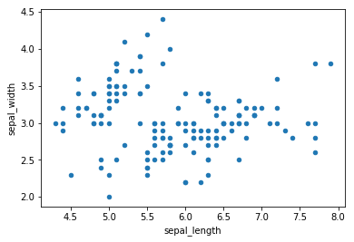

```python
iris.plot(kind='scatter', x='sepal_length', y='sepal_width')
plt.show()

# here the problem is we are not able to visualise ththree classes hence this is not useful
# We have to color the data points by their class
```

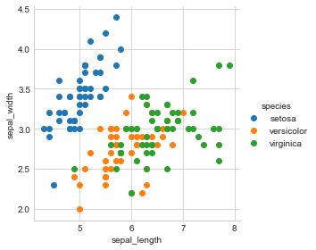

```python
sns.set_style("whitegrid");
sns.FacetGrid(iris, hue="species", size=4) \
   .map(plt.scatter, "sepal_length", "sepal_width") \
   .add_legend();
plt.show();
```

### Observation

##### 1) Here we are able to differentiate the data points of three diffentiate classes i.e setosa, versicolor, virginica.

##### 2) The problem here is we are not able to seperate the versicolor and virginica but setosa is well sepearated form rest of the two.

##### 3) The data point of versicolor and virginica are overlaping so it is not possible here to seperate both the flower.

##### 4) while setosa is much more seperable from the other two.

##### 5) So, now we have to try all such possible cases with 4 features avalaible by plotting taking 2 at a time.

##### 6) 4c2 = 6 such possible combinations.

# (Pair Plot)

### Can be used when number of features are high.

### NOTE: the diagnol elements are PDFs for each feature. PDFs are expalined below.

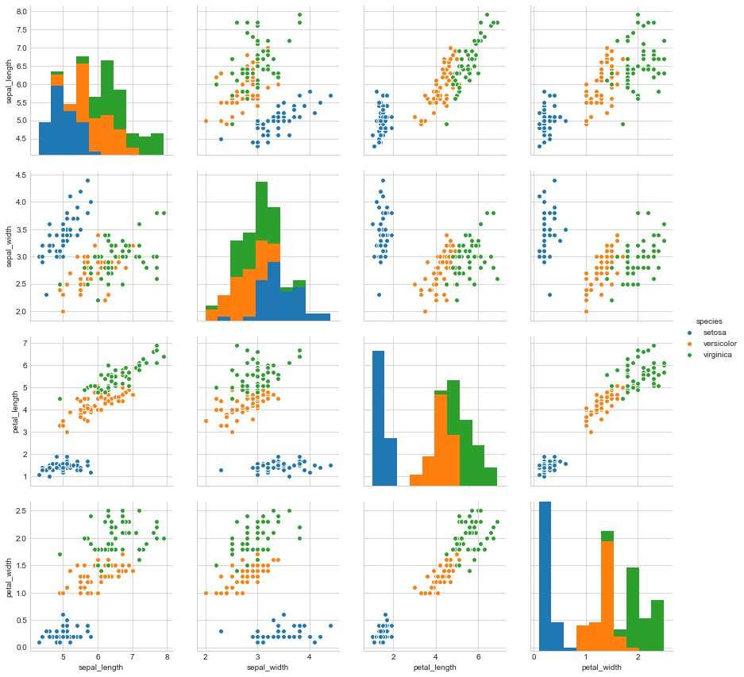

```python
plt.close();
sns.set_style("whitegrid");
sns.pairplot(iris, hue="species",size=3);
plt.show();
```

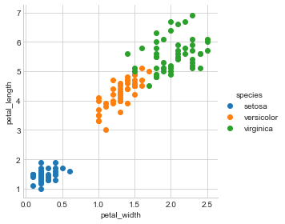

```python
sns.set_style("whitegrid");
sns.FacetGrid(iris, hue="species", size=4) \
   .map(plt.scatter, "petal_width", "petal_length") \
   .add_legend();
plt.show();
```

## Observation

Here, as you can see setosa must be clearly seperable and also rest of the two. Even if our model is not 100% effective but we are able to seperate three of the classes

Here what we can do is, we can make a simple model by writing a simple if else condition for seperating the three cases Case 1: if( (petal_width>=0 && petal_width<0.7 )&&(petal_length>=0 && petal_length<=2 )) print("setosa");

Case 2: if( (petal_width>=1 && petal_width<1.6 )&&(petal_length>=3 && petal_length<=5 )) print("versicolor");

Case 3: if( (petal_width>=1.6 && petal_width<2.5 )&&(petal_length>=5 && petal_length<=7 )) print("virginicar");

Case 4:(Deafult case) printf("No flower);

# Univaraite Analysis

#### Performing univariate analysis to understand which features are userful towards classification

#### 1. Pdf - Probability density function

#### 2. Cdf - Cumulative Distribution Function

#### 3. Box plot

#### 4. Violen plots

## 1-D scatter plot

##### In this plot we are just plotting point by taking x ccordinate or y ccordinate of a feature and making the other coordinate zero

##### 1-D scatter plot of petal length

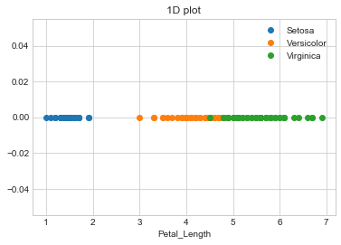

```python
import numpy as np
iris_setosa = iris.loc[iris["species"] == "setosa"]
iris_versicolor = iris.loc[iris["species"] == "versicolor"]
iris_virginica = iris.loc[iris["species"] == "virginica"]

plt.plot(iris_setosa["petal_length"], np.zeros_like(iris_setosa['petal_length']), 'o')
plt.plot(iris_versicolor["petal_length"], np.zeros_like(iris_versicolor['petal_length']), 'o')
plt.plot(iris_virginica["petal_length"], np.zeros_like(iris_virginica['petal_length']), 'o')
plt.legend(['Setosa', 'Versicolor', 'Virginica'])
plt.xlabel('Petal_Length')
plt.title('1D plot')

plt.show()
```

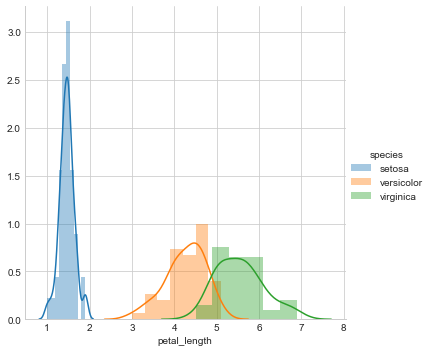

```python
#### Now Performing Histogram plot on the dataset taking a feature at a time
#### And then deciding which plot is more useful to classify it
sns.FacetGrid(iris, hue="species", size=5) \
   .map(sns.distplot, "petal_length") \
   .add_legend();
plt.show();
```

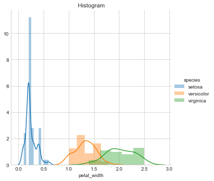

```python
sns.FacetGrid(iris, hue="species", size=5) \
   .map(sns.distplot, "petal_width") \
   .add_legend();
plt.title("Histogram")
plt.show();
```

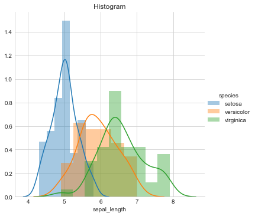

```python
sns.FacetGrid(iris, hue="species", size=5) \
   .map(sns.distplot, "sepal_length") \
   .add_legend();
plt.title("Histogram")
plt.show();
```

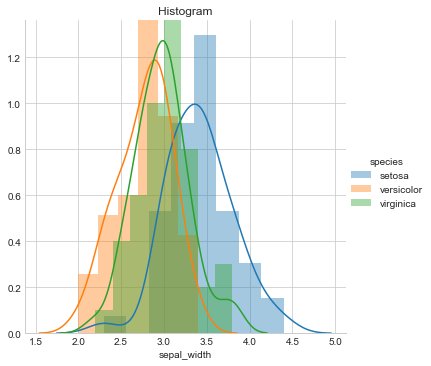

```python
sns.FacetGrid(iris, hue="species", size=5) \
   .map(sns.distplot, "sepal_width") \
   .add_legend();
plt.title("Histogram")
plt.show();
```